# Divisive clustering of Histogram Data

Marie Chavent

27/07/2021

- The crimes dataset concerns official data on violent crime occurence in the USA, together with some social indicators (see the [Communities and Crime Data Set](https://archive.ics.uci.edu/ml/datasets/communities+and+crime) on the UCI ML Repository). The data, recorded per county, were aggregated with the **HistDAWass** R package at state level in the form of histogram-valued data, .

```r
load("crimes_hist.rda")
```

```r
library(HistDAWass)
get.MatH.main.info(CRIMES)
```

```
## $nrows
## [1] 30
##
## $ncols
## [1] 5
##
## $rownames
##  [1] "AL" "AR" "AZ" "CA" "CO" "CT" "FL" "GA" "IA" "IN" "KY" "LA" "MA" "MO" "NC"
## [16] "NH" "NJ" "NY" "OH" "OK" "OR" "PA" "RI" "SC" "TN" "TX" "UT" "VA" "WA" "WI"
##
## $varnames
## [1] "pctLowEdu"      "pctEmploy"      "pctAllDivorc"   "pctFgnImmig.10"
## [5] "violentPerPop"
```

```r
get.cell.MatH(CRIMES,1,1) # histogram value of "AL" on "pctLowEdu
```

```
##                    X                  p
## Bin_1     [ 0.82 ; 8.6 )               0.25
## Bin_2    [ 8.6 ; 11.71 )               0.25
## Bin_3 [ 11.71 ; 15.415 )               0.25
## Bin_4 [ 15.415 ; 18.64 ]               0.25
##
##  mean =  11.36375   std  =  4.75675074017619
##
```

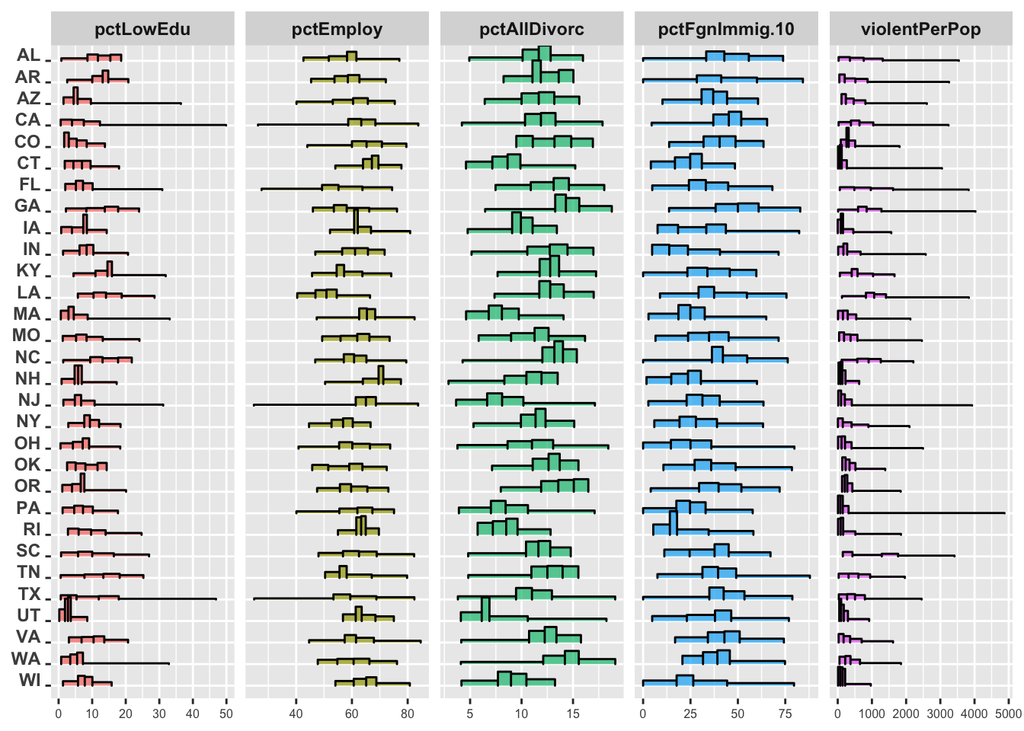

```r
plot(CRIMES, type = "HISTO")
```

- The Mallows distance (L2 Wasserstein distance) between the 30 states is calculated with the function **WH_MAT_DIST** of the R package **HistDAWass**. The histogram-valued data are standardized according to the procedure available in this function.

```r
DMAT <- WH_MAT_DIST(x = CRIMES, standardize = TRUE)
```

- The divisive clustering of the 30 states is performed with the **div_diss** function based on the **divclust** function of the **divclust** R package.

```r
source("div_diss.R")
source("choose_question_diss.R")
source("inertdiss-func.R")
```

```r
# Matrix of the medians values
M <- as.matrix(get.MatH.stats(CRIMES, stat = "median")$mat)
```

The **div_diss** function takes two values in input :

- The matrix **M** of the median values used to build the binary questions.
- The matrix **DMAT** of dissimilarities used to perform the criterion.

```
## Q3 : pctLowEdu < 12.52 or pctLowEdu >= 12.52
```

```
## Q4 : violentPerPop < 697.82 or violentPerPop >= 697.82
```

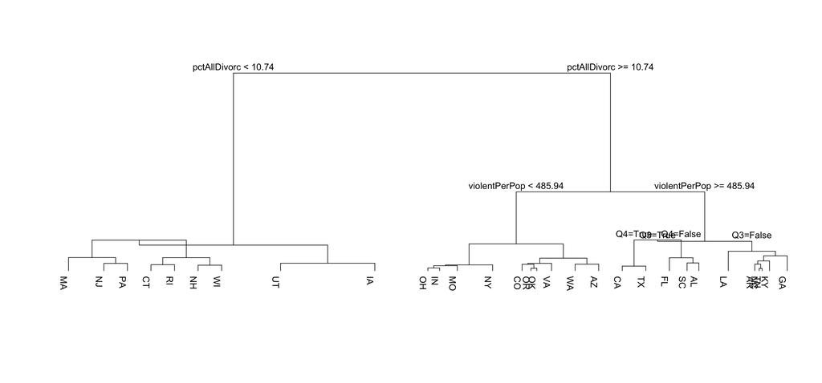

```r
# divisive clustering
library(divclust)
tree <- div_diss(data=M,as.dist(DMAT))
plot(tree, nqbin = 4)
```

- The number of clusters is chosen with the Silhouette Index.

```r
kmax <- 10
si <- rep(NA, kmax-1)
for (k in 2:kmax)
{
  partdiv <- div_diss(data=M,as.dist(DMAT), K=k)$which_cluster
  sidiv <- cluster::silhouette(partdiv, as.dist(DMAT))
  si[k-1] <- summary(sidiv)$avg.width
}
names(si) <- paste("k=",2:10, sep="")
```

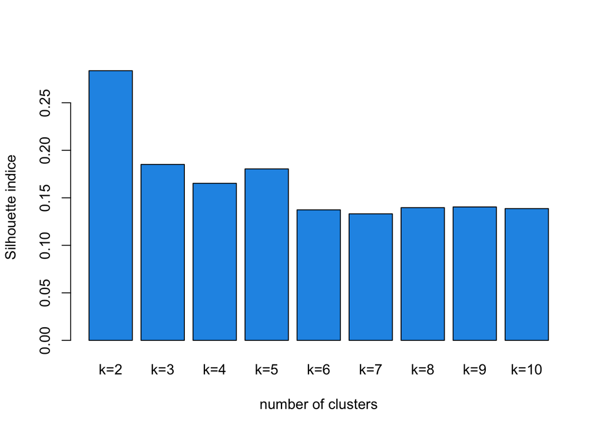

```r
barplot(si, col=4,
        xlab="number of clusters", ylab="Silhouette indice")
```

```r
# explained inertia
div_diss(data=M,as.dist(DMAT), K=2)$B #for k=2
```

```
## [1] 0.3295052
```

```r
div_diss(data=M,as.dist(DMAT), K=5)$B  #for k=5
```

```
## [1] 0.5613669
```

```r
tree <- div_diss(data=M,as.dist(DMAT), K=5)
tree$clusters
```

```
## $C1
## [1] "CT" "IA" "MA" "NH" "NJ" "PA" "RI" "UT" "WI"
##
## $C2
##  [1] "AZ" "CO" "IN" "MO" "NY" "OH" "OK" "OR" "VA" "WA"
##
## $C3
## [1] "AR" "GA" "KY" "LA" "NC" "TN"
##
## $C4
## [1] "CA" "TX"
##
## $C5
## [1] "AL" "FL" "SC"
```

```r
tree$description
```

```
## $C1
## [1] " pctAllDivorc = [-Inf ; 10.74["
##
## $C2
## [1] " pctAllDivorc = [10.74 ; Inf[ , violentPerPop = [-Inf ; 485.94["
##
## $C3
## [1] " pctAllDivorc = [10.74 ; Inf[ , violentPerPop = [485.94 ; Inf[ , pctLowEdu = [12.52 ; Inf["
##
## $C4
## [1] " pctAllDivorc = [10.74 ; Inf[ , violentPerPop = [485.94 ; 697.82[ , pctLowEdu = [-Inf ; 12.52["
##
## $C5
## [1] " pctAllDivorc = [10.74 ; Inf[ , violentPerPop = [697.82 ; Inf[ , pctLowEdu = [-Inf ; 12.52["
```

```r
partdiv <- tree$which_cluster
```

- Values of the Silhouette Index for the partitios in k = 5 clusters.

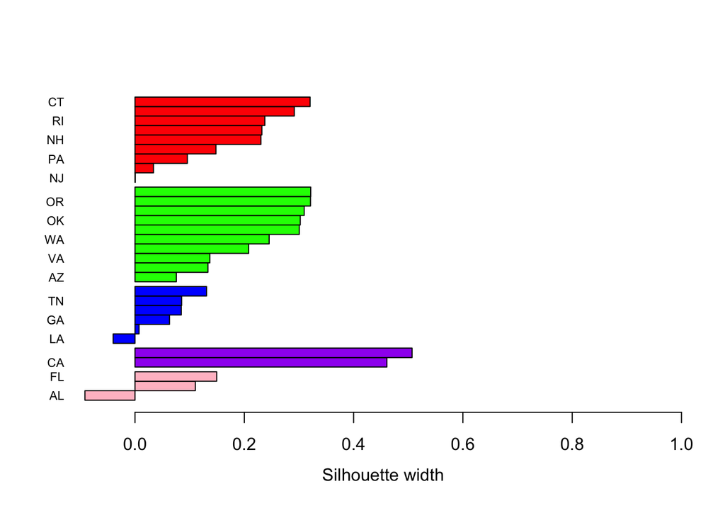

```r
sidiv <- cluster::silhouette(partdiv, as.dist(DMAT))
rownames(sidiv) <- rownames(DMAT)
plot(sidiv, cex.names = 0.7, main="",
     sub="", xlab="Silhouette width", border=1,
     do.clus.stat=FALSE, do.n.k=FALSE,
     col = c("red", "green", "blue", "purple", "pink"))
```

- Ward hierarchical clustering with Mallows distance (L2 Wasserstein distance).

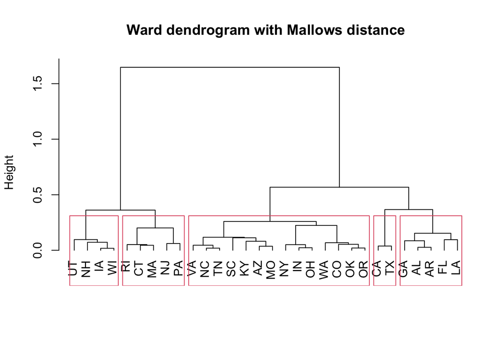

```r
n <- get.MatH.nrows(CRIMES)
tree <- hclust(as.dist(DMAT^2/(2*n)), method = "ward.D")
plot(tree, hang=-1, sub="", xlab="", main="Ward dendrogram with Mallows distance")
rect.hclust(tree, k=5)
```

```r
sum(tree$height[26:29])/ sum(tree$height) # 58.8 % of explained inertia
```

```
## [1] 0.5887834
```